# Diabetes Prediction

The following data was taken from Kaggle at: https://www.kaggle.com/mathchi/diabetes-data-set

The information pertains to data collected by the National Institute of Diabetes and Digestive and Kidney Diseases. All patients are female Pima Indians, which is a common heritage to assess the aetiology of diabetes due to very high prevalence rates. The data set comes with a series of variables related to diabetes diagnosis. A binary target variable is provided relating to a true diabetes test.

I will be using this largely to practice using the Reticulate package in R, which allows for transition between R and Python within a single R markdown workbook. I find this particularly useful as preprocessing and EDA is preferable in R, whereas machine learning is preferable in Python. I will provide guidance on doing so as we go along.

# Load Packages

```r
library(dplyr)
library(ggplot2)
library(ggthemes)
library(gridExtra)
library(corrplot)
library(missForest)
library(mice)
library(DMwR)
library(gridGraphics)
library(forcats)
```

# Load Data

```r
setwd('C:/Users/jaket/iCloudDrive/Kaggle/Diabetes_Prediction')

df<-read.csv('diabetes.csv')
```

# Basic initial exploration and EDA

Are there any NAs?

```r
colSums(is.na(df))
```

```
             Pregnancies                  Glucose            BloodPressure            SkinThickness                  Insulin
                       0                        0                        0                        0                        0
                     BMI DiabetesPedigreeFunction                      Age                  Outcome
                       0                        0                        0                        0
```

No NAs.

What is the format of the data

```r
str(df)
```

```
'data.frame':   768 obs. of  9 variables:
 $ Pregnancies             : int  6 1 8 1 0 5 3 10 2 8 ...
 $ Glucose                 : int  148 85 183 89 137 116 78 115 197 125 ...
 $ BloodPressure           : int  72 66 64 66 40 74 50 0 70 96 ...
 $ SkinThickness           : int  35 29 0 23 35 0 32 0 45 0 ...
 $ Insulin                 : int  0 0 0 94 168 0 88 0 543 0 ...
 $ BMI                     : num  33.6 26.6 23.3 28.1 43.1 25.6 31 35.3 30.5 0 ...
 $ DiabetesPedigreeFunction: num  0.627 0.351 0.672 0.167 2.288 ...
 $ Age                     : int  50 31 32 21 33 30 26 29 53 54 ...
 $ Outcome                 : int  1 0 1 0 1 0 1 0 1 1 ...
```

```r
df$Outcome<-as.factor(df$Outcome) # Factorize the outcome
```

What is the target ratio?

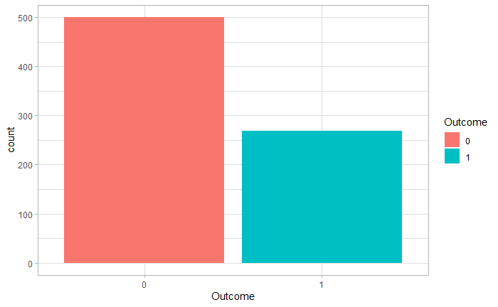

```r
ggplot(df, aes(x=Outcome, fill=Outcome))+geom_bar()+theme_light()
```

Over a third of the individuals were diagnosed with diabetes. Lets illustrate how the predictor variables relate to the outcome. It’s very possible that there are moderating variables in these relationships - for example, age may affect the BMI-risk relationship. Lets group some of these variables to explore more closely

```r
# Age groups
df$Age_group<-as.factor(ifelse(df$Age>18 &df$Age<=30, 'Young',
                     ifelse(df$Age>30 & df$Age <=50, 'MidAged',
                            ifelse(df$Age>50 & df$Age<=65, 'MidElderly', 'Elderly'))))

# BMI groups (typical medical cut offs)
df$BMI_group<-as.factor(ifelse(df$BMI>0 &df$BMI<25, 'NormalWeight',
                     ifelse(df$BMI>=25 & df$BMI <30, 'Overweight',
                            ifelse(df$BMI>=30 & df$BMI<35, 'ObeseC1', 'ObeseC2'))))
```

## Diabetes Pedigree function exploration

The Diabetes Pedigree function is a likelihood of diabetes based on family history and genetic factors.

Lets look at some physiological predictors by age and BMI groups. Note that it’s clear some people were not measured for some variables as values are assigned 0, we should change these to NA.

```r
# Where the value is 0 in any of the physiological columns, replace with NA
df[, 2:6][df[, 2:6]==0] <- NA
```

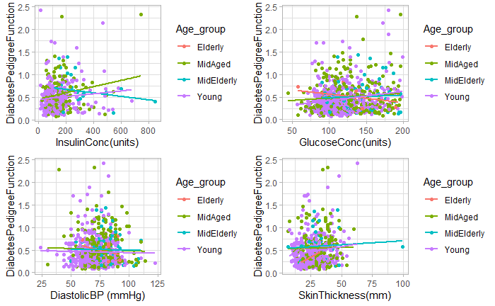

```r
p1<-ggplot(filter(df, Insulin>0), aes(x=Insulin, y=DiabetesPedigreeFunction, color=Age_group))+
  geom_point()+geom_smooth(method='lm', se=F)+theme_light()+xlab('InsulinConc(units)')
p2<-ggplot(filter(df, Glucose>0), aes(x=Glucose, y=DiabetesPedigreeFunction, color=Age_group))+
  geom_point()+geom_smooth(method='lm', se=F)+theme_light()+xlab('GlucoseConc(units)')
p3<-ggplot(filter(df, BloodPressure>0), aes(x=BloodPressure, y=DiabetesPedigreeFunction, color=Age_group))+
  geom_point()+geom_smooth(method='lm', se=F)+theme_light()+xlab('DiastolicBP (mmHg)')
p4<-ggplot(filter(df, SkinThickness>0), aes(x=SkinThickness, y=DiabetesPedigreeFunction, color=Age_group))+
  geom_point()+geom_smooth(method='lm', se=F)+theme_light()+xlab('SkinThickness(mm)')

grid.arrange(p1,p2,p3,p4)
```

There are no clear associations here between any of these physiological measurements and DPF, and furthermore we don’t seem to see a moderating effect of age. Lets see if there’s any evidence that BMI moderates these effects.

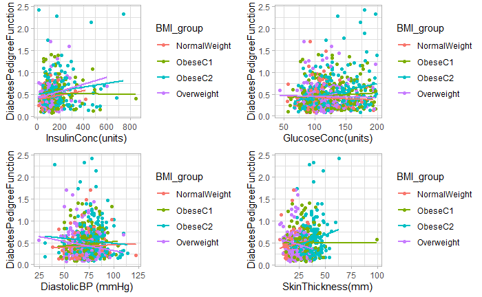

```r
p1<-ggplot(filter(df, Insulin>0), aes(x=Insulin, y=DiabetesPedigreeFunction, color=BMI_group))+
  geom_point()+geom_smooth(method='lm', se=F)+theme_light()+xlab('InsulinConc(units)')
p2<-ggplot(filter(df, Glucose>0), aes(x=Glucose, y=DiabetesPedigreeFunction, color=BMI_group))+
  geom_point()+geom_smooth(method='lm', se=F)+theme_light()+xlab('GlucoseConc(units)')
p3<-ggplot(filter(df, BloodPressure>0), aes(x=BloodPressure, y=DiabetesPedigreeFunction, color=BMI_group))+
  geom_point()+geom_smooth(method='lm', se=F)+theme_light()+xlab('DiastolicBP (mmHg)')
p4<-ggplot(filter(df, SkinThickness>0), aes(x=SkinThickness, y=DiabetesPedigreeFunction, color=BMI_group))+
  geom_point()+geom_smooth(method='lm', se=F)+theme_light()+xlab('SkinThickness(mm)')

grid.arrange(p1,p2,p3,p4)
```

Here we can see positive associations between Insulin and DPF, though it does not appear to be moderated by BMI.

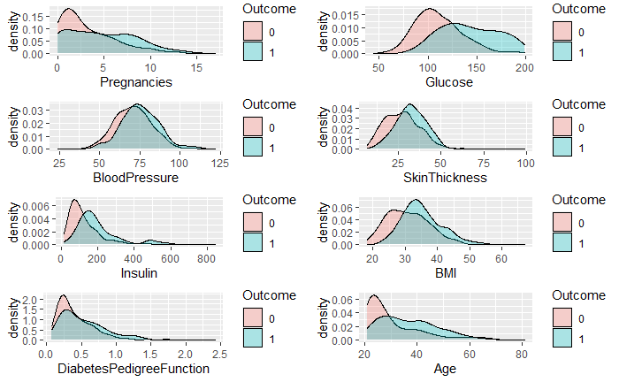

```r
vars=colnames(df[, !names(df) %in% c("Age_group", "BMI_group", "Outcome")])

j=1
dist_list<-list()
for (i in vars){
  dist_list[[j]]<-ggplot(df, aes_string(x=i, fill='Outcome')) + geom_density(alpha=.3)+xlab(paste0(i))
  j=j+1
}

n <- length(dist_list)
nCol <- floor(sqrt(n))
do.call("grid.arrange", c(dist_list, ncol=nCol))
```

From this we can see that greater incidence of diabetes tends to be associated with: + More pregnancies + Higher glucose + Greater skin thickness + Greater insulin + Greater BMI + Greater age

The associations with blood pressure and DPF look weaker but there is some evidence.

Importantly, for modelling purposes it’s vital to note that these variables are probably highly multicollinear. We can produce a quite correlogram to check. A lot of participants have missing data - for now we’ll look at the correlation of complete obs, and we can check this agai following imputation.

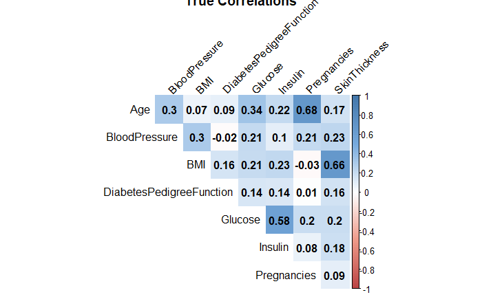

```r
cor_df<-df[vars]%>%na.omit()
cors<-cor(cor_df)
col <- colorRampPalette(c("#BB4444", "#EE9988", "#FFFFFF", "#77AADD", "#4477AA"))
true_cors<-corrplot(cors, method="color", col=col(200),
         type="upper", order="alphabet",
         addCoef.col = "black", # Add coefficient of correlation
         tl.col="black", tl.srt=45, #Text label color and rotation
         diag=FALSE, title='True Correlations'
         )
```

```r
true_cors
```

```
                                Age BloodPressure         BMI DiabetesPedigreeFunction   Glucose    Insulin  Pregnancies SkinThickness
Age                      1.00000000     0.3000389  0.06981380              0.085029106 0.3436415 0.21708199  0.679608470     0.1677611
BloodPressure            0.30003895     1.0000000  0.30440337             -0.015971104 0.2100266 0.09851150  0.213354775     0.2325712
BMI                      0.06981380     0.3044034  1.00000000              0.158771043 0.2095159 0.22639652 -0.025347276     0.6643549
DiabetesPedigreeFunction 0.08502911    -0.0159711  0.15877104              1.000000000 0.1401802 0.13590578  0.007562116     0.1604985
Glucose                  0.34364150     0.2100266  0.20951592              0.140180180 1.0000000 0.58122301  0.198291043     0.1988558
Insulin                  0.21708199     0.0985115  0.22639652              0.135905781 0.5812230 1.00000000  0.078983625     0.1821991
Pregnancies              0.67960847     0.2133548 -0.02534728              0.007562116 0.1982910 0.07898363  1.000000000     0.0932094
SkinThickness            0.16776114     0.2325712  0.66435487              0.160498526 0.1988558 0.18219906  0.093209397     1.0000000
```

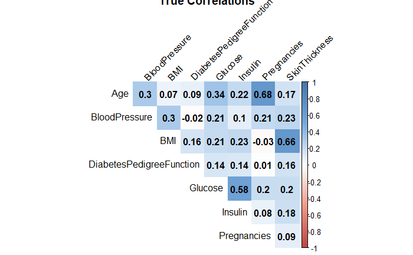

```r
# I'm going to grab this because later i'll need it for a grid arrange
grid.echo()
```

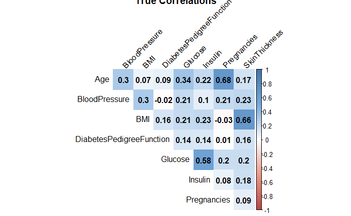

```r
P1 <- grid.grab()
```

A lot of these correlations are surprisingly low. For example, one might expect MMI to be more closely related to health markers, but these associations are weak. This may make imputation more difficult.

## Imputation

I’m going to try 3 different approaches and see how they compare. We’ll use an RF approach (missForest), a KNN imputation (DMwR) and a predictive means matching approach (MICE).

```r
df$ID<-seq(1:nrow(df))
numerics<-select_if(df, is.numeric)

# I use out of the box settings for these
knn_df <-knnImputation(numerics)
rf_df <-missForest(numerics)$ximp
```

```
  missForest iteration 1 in progress...done!
  missForest iteration 2 in progress...done!
  missForest iteration 3 in progress...done!
```

```r
# Mice is a little more complicated as it generates m data sets, we can extract these then take the mean of all variables per ID.
pmm_df<-mice(numerics, m = 5, method = "pmm")%>%complete(., action='all')%>%
  bind_rows()%>%group_by(ID)%>%dplyr::summarise_all(mean)
```

Now lets see how the correlations compare to the true correlation.

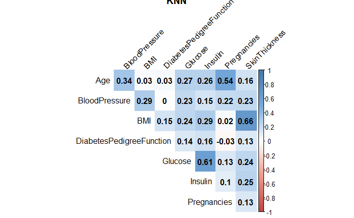

```r
#Generate correlations
knn_df_cor<-knn_df%>%select(-ID)%>%cor()
rf_df_cor<-rf_df%>%select(-ID)%>%cor()
pmm_df_cor<-pmm_df%>%select(-ID)%>%cor()

#Generate plots
knn_cors<-corrplot(knn_df_cor, method="color", col=col(200),
         type="upper", order="alphabet",
         addCoef.col = "black",
         tl.col="black", tl.srt=45,
         diag=FALSE, title='KNN'
         )
```

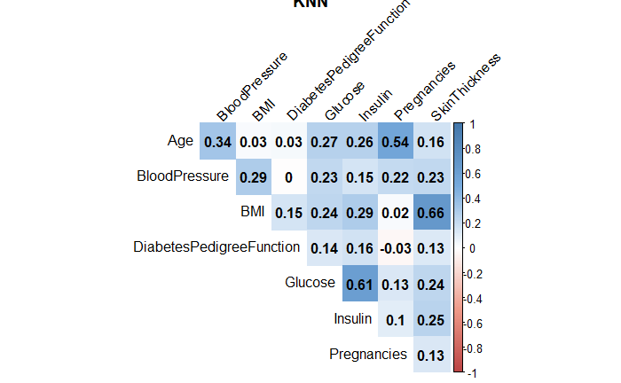

```r
grid.echo()
```

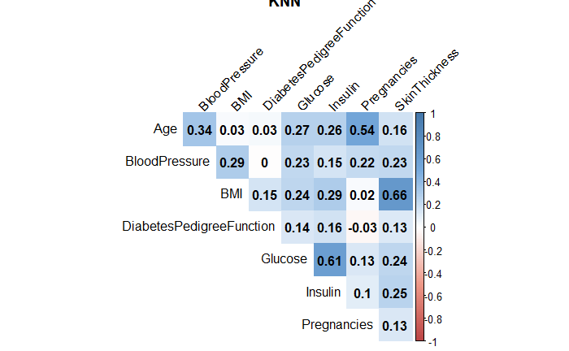

```r
P2 <- grid.grab()
```

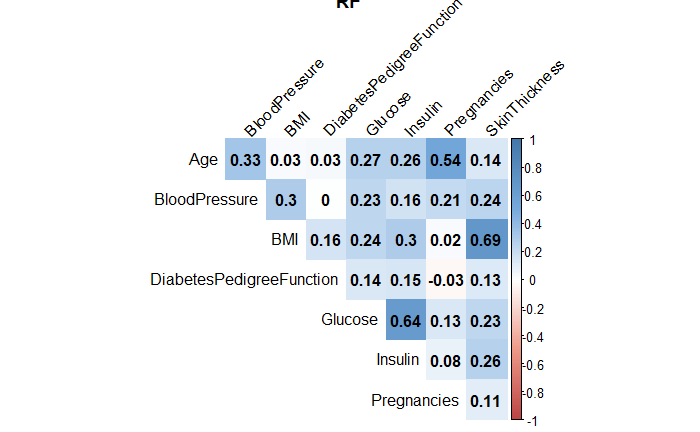

```r
rf_cors<-corrplot(rf_df_cor, method="color", col=col(200),
         type="upper", order="alphabet",
         addCoef.col = "black",
         tl.col="black", tl.srt=45,
         diag=FALSE, title='RF'
         )
```

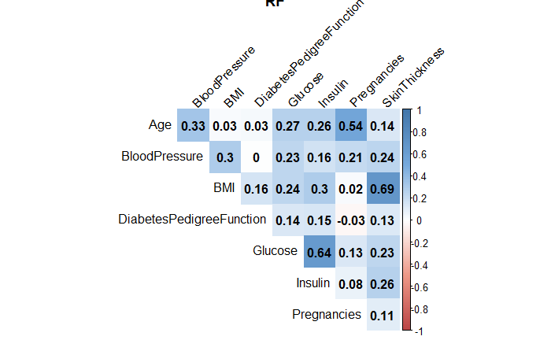

```r
grid.echo()
```

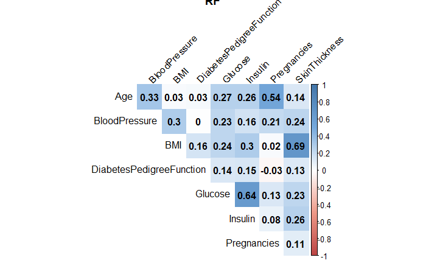

```r
P3 <- grid.grab()
```

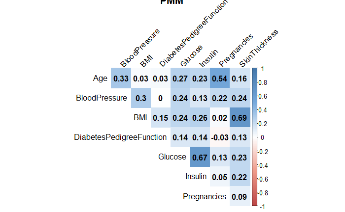

```r
pmm_cors<-corrplot(pmm_df_cor, method="color", col=col(200),
         type="upper", order="alphabet",
         addCoef.col = "black",
         tl.col="black", tl.srt=45,
         diag=FALSE, title='PMM'
         )
```

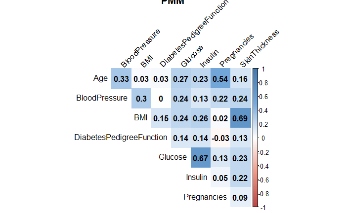

```r
grid.echo()
```

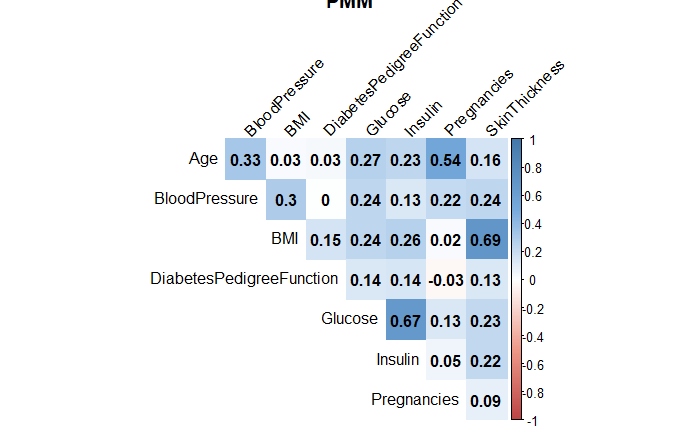

```r
P4 <- grid.grab()
```

```r
NA
NA
```

Compare correlations of true vs imputed data sets

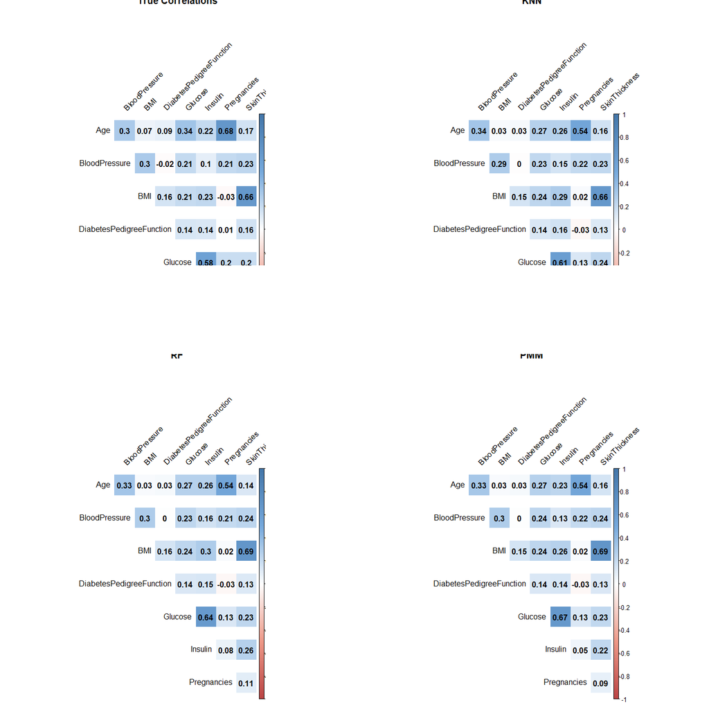

```r
grid.arrange(P1, P2, P3, P4)
```

It seems that, despite over doubling the sample size, the variable associations remain similar for all imputation dfs. Based on slightly closer correlations, I’m going to use the KNN df from here on.

## Feature engineering

Lets use some domain knowledge on diabetes diagnosis. The American Diabetes Association and WHO states that fasting glucose >126 is one threshold for diagnosis, and 110-125 is considered pre-diabetes, so we’ll generate this variable.

```r
# Merge the variables we removed during imputation back in
knn_df<-df%>%dplyr::select(ID, Age_group, BMI_group, Outcome)%>%merge(knn_df, ., by='ID')

knn_df$glucose_threshold<-as.factor(ifelse(
  knn_df$Glucose < 110, 0,
  ifelse(knn_df$Glucose>= 110 & knn_df$Glucose < 126, 1, 2)
))
```

HOMA-IR is a universally used insulin resistance score which compares insulin and glucose levels. It can be considered closely related to diabetes. Lets calculate the value from known formula.

```r
knn_df$HOMA <- (knn_df$Insulin * knn_df$Glucose)/405
```

These values seem high (probably because of the units), but it is more the mathematical interaction between insulin and glucose we’re interested in.

Skin thickness is a marker of body fat (%), BMI is a similar metric but does not estimate fatness (is just a ratio between height and weight). There are differences in fatness at a given BMI. Therefore, we can create a ratio of these two variables which may provide further information. Evidence: https://www.researchgate.net/publication/259920627_Effects_of_Age_Gender_BMI_and_Anatomical_Site_on_Skin_Thickness_in_Children_and_Adults_with_Diabetes

```r
knn_df$BMI_fatness<-knn_df$BMI / knn_df$SkinThickness

# But skin thickness is also associated with age

knn_df$BMI_fatness_age<-(knn_df$BMI / knn_df$SkinThickness)*knn_df$Age
```

Lastly, lets label encode the grouping variables

```r
knn_df<-knn_df%>%mutate(Age_group=fct_relevel(Age_group, 'Young', 'MidAged', 'MidElderly', 'Elderly'),
                        BMI_group=fct_relevel(BMI_group, 'NormalWeight', 'Overweight', 'ObeseC1', 'ObeseC2'))

knn_df$Age_group<-as.integer(factor(knn_df$Age_group))
knn_df$BMI_group<-as.integer(factor(knn_df$BMI_group))
```

## Switching to Python (reticulate)

Now we’ve done some brief processing, I’m going to switch to Python to take advantage of the machine learning architecture available.

A full guide to using Python within R can be found at: https://rstudio.github.io/reticulate/articles/python_packages.html and here: https://rstudio.github.io/reticulate/articles/r_markdown.html

To do this, we use: + Install and load the R package ‘reticulate’ in R Markdown. + Install Miniconda + Create a conda environment + Install additional packages (e.g. sklearn) + repl_python() will provides a Python REPL embedded console within your R session

```r
library(reticulate)
if(.Platform$OS.type == "windows")Sys.setenv(PATH=paste("D:/anaconda3/Library/bin",Sys.getenv()["PATH"],sep=";"))

conda_list()                  # List available environments
```

| name | python |
| --- | --- |
| r-miniconda | C:\\Users\\jaket\\AppData\\Local\\r-miniconda\\python.exe |
| r-reticulate | C:\\Users\\jaket\\AppData\\Local\\r-miniconda\\envs\\r-reticulate\\python.exe |
| anaconda3 | D:\\Users\\jaket\\anaconda3\\python.exe |
| pandas | D:\\Users\\jaket\\anaconda3\\envs\\pandas\\python.exe |
| r-reticulate | D:\\Users\\jaket\\anaconda3\\envs\\r-reticulate\\python.exe |

```r
use_condaenv("r-reticulate")  # Select your environment
```

|  | name | python |
| --- | --- | --- |
| 2 | r-reticulate | C:\\Users\\jaket\\AppData\\Local\\r-miniconda\\envs\\r-reticulate\\python.exe |
| 5 | r-reticulate | D:\\Users\\jaket\\anaconda3\\envs\\r-reticulate\\python.exe |

```r
py_available(TRUE)
```

```
[1] TRUE
```

```r
py_config()
```

```
python:         C:/Users/jaket/AppData/Local/r-miniconda/envs/r-reticulate/python.exe
libpython:      C:/Users/jaket/AppData/Local/r-miniconda/envs/r-reticulate/python36.dll
pythonhome:     C:/Users/jaket/AppData/Local/r-miniconda/envs/r-reticulate
version:        3.6.11 (default, Aug  5 2020, 19:41:03) [MSC v.1916 64 bit (AMD64)]
Architecture:   64bit
numpy:          C:/Users/jaket/AppData/Local/r-miniconda/envs/r-reticulate/Lib/site-packages/numpy
numpy_version:  1.18.5
```

### Load python packages

Convert the training and testing dfs to python. This will make it accessible via pandas. In order to call the object in a python chunk we use ‘r.df’

```
   ID  Pregnancies  Glucose  ...        HOMA  BMI_fatness  BMI_fatness_age
0   1            6    148.0  ...  104.731626     0.960000        48.000000
1   2            1     85.0  ...   11.836225     0.917241        28.434483
2   3            8    183.0  ...  100.132916     0.764592        24.466930
3   4            1     89.0  ...   20.656790     1.221739        25.656522
4   5            0    137.0  ...   56.829630     1.231429        40.637143

[5 rows x 16 columns]
```

Perfect - now we have the converted pandas df.

Next, we want to split this data set into train and test data. Typically, about 70-80% of the data is used to train the model. However, I note that one 2017 publication using this data set (see below) used only 20% data to train and 80% to test. To see if I can compare with their model performance, I will use this approach for now.

Diabetes Mellitus Affected Patients Classification and Diagnosis through Machine Learning Techniques (Mercaldo, 2017)

It is important to note that this paper does not mention imputation, and I believe that the original dataset they use is complete. Therefore, to match their performance we are relying on good imputation

```
     Pregnancies  Glucose  ...  BMI_fatness  BMI_fatness_age
505           10     75.0  ...     0.941813        35.788904
756            7    137.0  ...     0.780488        30.439024
710            3    158.0  ...     2.400000        57.600000
693            7    129.0  ...     0.785714        33.785714
658           11    127.0  ...     1.119659        57.102630

[5 rows x 14 columns]
```

Given that we have only 2 outcome levels, we’ll treat it as a classification (clf) problem. Lets define some clfs that we’ll use.

```python
classifiers = [
    KNeighborsClassifier(3),
    DecisionTreeClassifier(),
    RandomForestClassifier(),
    GradientBoostingClassifier(),
    LinearDiscriminantAnalysis(),
    MLPClassifier(random_state = 42)]
```

[output not shown]

## Variable importance

Which variables are most important? We’ll use the RF model to check as it has a built in importance feature

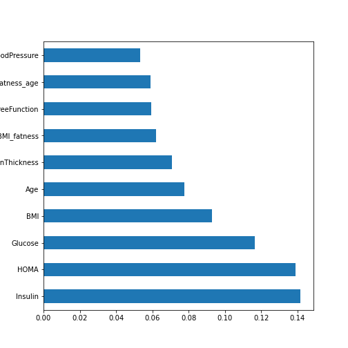

```python
rf = RandomForestClassifier(n_estimators=500)
rf.fit(X_train, y_train);
feat_importances = pd.Series(rf.feature_importances_, index=X_train.columns)
feat_importances.nlargest(10).plot(kind='barh')
```

As expected, HOMA, glucose and insulin are the best predictors.

## Stacking

Lets see if we can stack some basic clf models to improve the performance. After we’ll consider tuning.

We’ll use RF and XGB as features in an LDA meta-clf.

```python
RF = RandomForestClassifier(random_state = 42)
LD = LinearDiscriminantAnalysis()
XGB= GradientBoostingClassifier()
```

Define stack

```python
stack = StackingCVClassifier(classifiers=[RF, XGB],
                            use_probas=True, # this will use probabilities of the 3 classifiers as meta-features in the meta-classifier model
                            meta_classifier=LD,
                            random_state=42)
```

Run stack

```
Accuracy: 0.71 (+/- 0.02) [Random Forest]
Accuracy: 0.70 (+/- 0.06) [GradientBoost]
Accuracy: 0.72 (+/- 0.01) [LD]
Accuracy: 0.72 (+/- 0.04) [StackingClassifer]
```

## Tuning

The stacking of classifiers doesnt add much. There isn’t much tuning capacity in LDA, but we can tune the XGB and RFs and see as if they operate as better models.

Lets run a random search on the RF. First, define grid.

```python
from sklearn.model_selection import RandomizedSearchCV

n_estimators = [int(x) for x in np.linspace(start = 200, stop = 2000, num = 10)]
max_features = ['auto', 'sqrt']
max_depth = [int(x) for x in np.linspace(10, 110, num = 11)]
max_depth.append(None)
min_samples_split = [2, 5, 10]
min_samples_leaf = [1, 2, 4]
bootstrap = [True, False]
random_grid = {'n_estimators': n_estimators,
               'max_features': max_features,
               'max_depth': max_depth,
               'min_samples_split': min_samples_split,
               'min_samples_leaf': min_samples_leaf,
               'bootstrap': bootstrap}
```

Run search.

```
RandomizedSearchCV(cv=3, estimator=RandomForestClassifier(random_state=42),
                   n_iter=100,
                   param_distributions={'bootstrap': [True, False],
                                        'max_depth': [10, 20, 30, 40, 50, 60,
                                                      70, 80, 90, 100, 110,
                                                      None],
                                        'max_features': ['auto', 'sqrt'],
                                        'min_samples_leaf': [1, 2, 4],
                                        'min_samples_split': [2, 5, 10],
                                        'n_estimators': [200, 400, 600, 800,
                                                         1000, 1200, 1400, 1600,
                                                         1800, 2000]},
                   random_state=42)
```

Compare RF to base model to check improvement

```
Improvement of 0.22%.
```

A minor improvement in the RF clf.

Run a random search on the XGB model

```
RandomizedSearchCV(cv=3, estimator=GradientBoostingClassifier(), n_iter=100,
                   param_distributions={'learning_rate': [0.05, 0.1, 0.2, 0.3,
                                                          0.5],
                                        'max_depth': [1, 5, 10, 15, 20],
                                        'n_estimators': [200, 300, 400, 500,
                                                         600],
                                        'subsample': [0.5, 0.75, 1]},
                   random_state=42)
```

Compare the XGB to base model

```
Improvement of 0.22%.
```

Again, a very small improvement.

We could now use these in a final stacked model.

[output not shown]